# Ports R Project

2024-05-22

# Discovering the Data

### Downloading the datasets

```r
ports_data <- read_excel("~/Downloads/ports.xlsx")
geography_data <- read_excel("~/Downloads/geographical_location.xlsx")
```

Using read_excel function we upload the excel data sets from UN Global Platform and IMF PortWatch.

### Inspecting the Data that we have

```r
head(ports_data, 5) # head function provides the first 5 rows of the ports data set
```

```
## # A tibble: 5 × 10
##   portid   fullname          industry_top1           industry_top2 industry_top3
##   <chr>    <chr>             <chr>                   <chr>         <chr>
## 1 port1325 Tsuruga Ko, Japan Petroleum, Chemical an… Mining and Q… Agriculture
## 2 port1325 Tsuruga Ko, Japan Petroleum, Chemical an… Mining and Q… Agriculture
## 3 port1325 Tsuruga Ko, Japan Petroleum, Chemical an… Mining and Q… Agriculture
## 4 port1325 Tsuruga Ko, Japan Petroleum, Chemical an… Mining and Q… Agriculture
## 5 port1325 Tsuruga Ko, Japan Petroleum, Chemical an… Mining and Q… Agriculture
## # ℹ 5 more variables: share_country_maritime_import <chr>,
## #   share_country_maritime_export <chr>, LOCODE <chr>, vessel_type <chr>,
## #   vessel_count <dbl>
```

```r
summary(ports_data) # summary provides Length, Class, Mode for each variable in the ports data set
```

```
##     portid            fullname         industry_top1      industry_top2
##  Length:8268        Length:8268        Length:8268        Length:8268
##  Class :character   Class :character   Class :character   Class :character
##  Mode  :character   Mode  :character   Mode  :character   Mode  :character
##
##
##
##  industry_top3      share_country_maritime_import share_country_maritime_export
##  Length:8268        Length:8268                   Length:8268
##  Class :character   Class :character              Class :character
##  Mode  :character   Mode  :character              Mode  :character
##
##
##
##     LOCODE          vessel_type         vessel_count
##  Length:8268        Length:8268        Min.   :     0.0
##  Class :character   Class :character   1st Qu.:     5.0
##  Mode  :character   Mode  :character   Median :    69.0
##                                        Mean   :   503.4
##                                        3rd Qu.:   285.0
##                                        Max.   :122404.0
```

```r
head(geography_data, 5) # head function provides the first 5 rows of the geography data set for a quick overlook of variables
```

```
## # A tibble: 5 × 6
##   portname     country     ISO3  continent      latitude   lon
##   <chr>        <chr>       <chr> <chr>             <dbl> <dbl>
## 1 Tsuruga Ko   Japan       JPN   Asia & Pacific    35.7  136.
## 2 Sibolga      Indonesia   IDN   Asia & Pacific     1.73  98.8
## 3 Fang-Cheng   China       CHN   Asia & Pacific    21.6  108.
## 4 Ube Ko       Japan       JPN   Asia & Pacific    33.9  131.
## 5 Bluff Harbor New Zealand NZL   Asia & Pacific   -46.6  168.
```

```r
summary(geography_data) # summary provides Length, Class, Mode for each variable in the geography data set
```

```
##    portname           country              ISO3            continent
##  Length:1378        Length:1378        Length:1378        Length:1378
##  Class :character   Class :character   Class :character   Class :character
##  Mode  :character   Mode  :character   Mode  :character   Mode  :character
##
##
##
##     latitude            lon
##  Min.   :-53.130   Min.   :-175.18
##  1st Qu.:  7.919   1st Qu.: -16.97
##  Median : 31.406   Median :  17.52
##  Mean   : 24.551   Mean   :  28.67
##  3rd Qu.: 43.406   3rd Qu.: 112.70
##  Max.   : 70.662   Max.   : 179.36
```

### How many variables does each data set have?

```r
ncol(ports_data) # the ports data set consists of 10 variables, each representing different attributes collected within the set.
```

```
## [1] 10
```

```r
ncol(geography_data) # the geography set has 6 variables
```

```
## [1] 6
```

### How many observations per variable do we have?

```r
nrow(ports_data) # as we can see, there are 8268 observations in each variable in the ports data set
```

```
## [1] 8268
```

```r
nrow(geography_data) # and 1378 observations in the geography set
```

```
## [1] 1378
```

### What do the variable names mean?

> Variables represent the data values that we have in the data set. They also have descriptive names, so that it’ll be easier to use them for the analysis.

### What variable types are we dealing with?

```r
str(ports_data)
```

```
## tibble [8,268 × 10] (S3: tbl_df/tbl/data.frame)
##  $ portid                       : chr [1:8268] "port1325" "port1325" "port1325" "port1325" ...
##  $ fullname                     : chr [1:8268] "Tsuruga Ko, Japan" "Tsuruga Ko, Japan" "Tsuruga Ko, Japan" "Tsuruga Ko, Japan" ...
##  $ industry_top1                : chr [1:8268] "Petroleum, Chemical and Non-Metallic Mineral Products" "Petroleum, Chemical and Non-Metallic Mineral Products" "Petroleum, Chemical and Non-Metallic Mineral Products" "Petroleum, Chemical and Non-Metallic Mineral Products" ...
##  $ industry_top2                : chr [1:8268] "Mining and Quarrying" "Mining and Quarrying" "Mining and Quarrying" "Mining and Quarrying" ...
##  $ industry_top3                : chr [1:8268] "Agriculture" "Agriculture" "Agriculture" "Agriculture" ...
##  $ share_country_maritime_import: chr [1:8268] "0'3" "0'3" "0'3" "0'3" ...
##  $ share_country_maritime_export: chr [1:8268] "8.9999999999999998E-4" "8.9999999999999998E-4" "8.9999999999999998E-4" "8.9999999999999998E-4" ...
##  $ LOCODE                       : chr [1:8268] "NA" "NA" "NA" "NA" ...
##  $ vessel_type                  : chr [1:8268] "total" "container" "dry_bulk" "general_cargo" ...
##  $ vessel_count                 : num [1:8268] 704 28 112 103 416 42 53 11 0 10 ...
```

```r
str(geography_data)
```

```
## tibble [1,378 × 6] (S3: tbl_df/tbl/data.frame)
##  $ portname : chr [1:1378] "Tsuruga Ko" "Sibolga" "Fang-Cheng" "Ube Ko" ...
##  $ country  : chr [1:1378] "Japan" "Indonesia" "China" "Japan" ...
##  $ ISO3     : chr [1:1378] "JPN" "IDN" "CHN" "JPN" ...
##  $ continent: chr [1:1378] "Asia & Pacific" "Asia & Pacific" "Asia & Pacific" "Asia & Pacific" ...
##  $ latitude : num [1:1378] 35.67 1.73 21.61 33.94 -46.59 ...
##  $ lon      : num [1:1378] 136.1 98.8 108.4 131.2 168.4 ...
```

> So, as we can see, the geography data set includes mostly *character* and *numeric* variables. Meanwhile, the ports set has also both *character* and *numeric* variables, with the majority being *character* variables.

### Are there any mistakes with the variable types that might make future work difficult if not fixed?

> Yes, there some mistakes, as variables *“share_country_maritime_import”* and the same varible with *export* stored as character strings but represent numeric data. Moreover, the variable *“LOCODE”* in the ports data set contains NA that should be deleted.

> This misclassification can make our future data analysis and visualization process difficult, as numerical operations and statistics can’t be done directly on chr data. So, we should convert first these variables for future work.

### Is the dataset in long or wide format? Do you need to change that later?

> Both datasets are in long format. It’ll be easier to visualize and analyse data further in the wide format.

## Cleaning Ports Variables

```r
ports_data <- ports_data %>%
  mutate(share_country_maritime_import = as.numeric(gsub("'", ".", share_country_maritime_import)),
         share_country_maritime_export = as.numeric(share_country_maritime_export)) # Export column is ready from the beginning to be converted into numeric
str(ports_data) # checking the numeric formats by two variables
```

```
## tibble [8,268 × 10] (S3: tbl_df/tbl/data.frame)
##  $ portid                       : chr [1:8268] "port1325" "port1325" "port1325" "port1325" ...
##  $ fullname                     : chr [1:8268] "Tsuruga Ko, Japan" "Tsuruga Ko, Japan" "Tsuruga Ko, Japan" "Tsuruga Ko, Japan" ...
##  $ industry_top1                : chr [1:8268] "Petroleum, Chemical and Non-Metallic Mineral Products" "Petroleum, Chemical and Non-Metallic Mineral Products" "Petroleum, Chemical and Non-Metallic Mineral Products" "Petroleum, Chemical and Non-Metallic Mineral Products" ...
##  $ industry_top2                : chr [1:8268] "Mining and Quarrying" "Mining and Quarrying" "Mining and Quarrying" "Mining and Quarrying" ...
##  $ industry_top3                : chr [1:8268] "Agriculture" "Agriculture" "Agriculture" "Agriculture" ...
##  $ share_country_maritime_import: num [1:8268] 0.3 0.3 0.3 0.3 0.3 0.3 0.08 0.08 0.08 0.08 ...
##  $ share_country_maritime_export: num [1:8268] 9e-04 9e-04 9e-04 9e-04 9e-04 9e-04 2e-04 2e-04 2e-04 2e-04 ...
##  $ LOCODE                       : chr [1:8268] "NA" "NA" "NA" "NA" ...
##  $ vessel_type                  : chr [1:8268] "total" "container" "dry_bulk" "general_cargo" ...
##  $ vessel_count                 : num [1:8268] 704 28 112 103 416 42 53 11 0 10 ...
```

```r
# In the ports data set we need to convert two columns with Import and Export. In share_country_maritime_import we need to change from "'" to "." and then convert to numeric format.
```

## Cleaning Geographical Location Variables

```r
geography_data <- geography_data %>%
  mutate(latitude = as.numeric(latitude), # converting latitude and longitude to num type
lon = as.numeric(lon)) %>%
rename(lat = latitude, long = lon) # using rename function from dplyr I rename two variables
str(geography_data) # checking the new formats and names
```

```
## tibble [1,378 × 6] (S3: tbl_df/tbl/data.frame)
##  $ portname : chr [1:1378] "Tsuruga Ko" "Sibolga" "Fang-Cheng" "Ube Ko" ...
##  $ country  : chr [1:1378] "Japan" "Indonesia" "China" "Japan" ...
##  $ ISO3     : chr [1:1378] "JPN" "IDN" "CHN" "JPN" ...
##  $ continent: chr [1:1378] "Asia & Pacific" "Asia & Pacific" "Asia & Pacific" "Asia & Pacific" ...
##  $ lat      : num [1:1378] 35.67 1.73 21.61 33.94 -46.59 ...
##  $ long     : num [1:1378] 136.1 98.8 108.4 131.2 168.4 ...
```

# Discovering Ports

Sorting and Rearranging the data

```r
selected_ports <- ports_data %>%
  dplyr::select("fullname", "vessel_type", "vessel_count") # because of conflicting packages and commands, having the same name, I specify the dplyr select package
```

```r
ports_sum <- selected_ports %>%
  filter(vessel_type == "total") %>%
  group_by(fullname) %>%
  summarise(vessels_sum = sum(vessel_count, na.rm = TRUE)) %>%
  arrange(desc(vessels_sum))

top15_ports <- ports_sum %>%
  slice_max(order_by = vessels_sum, n=15)
```

Plotting the results:

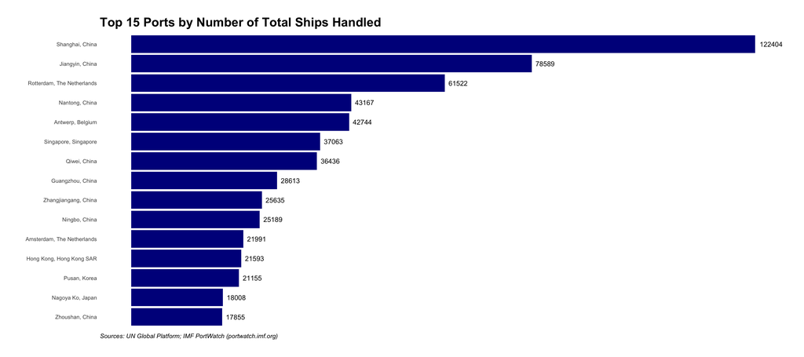

```r
ggplot(top15_ports, aes(x = reorder(fullname, vessels_sum),y=vessels_sum)) +
  geom_bar(stat = "identity", fill = "darkblue") +
  coord_flip() +
  geom_text(aes(label=vessels_sum), hjust = -0.2, color="black")+
  labs(title= "Top 15 Ports by Number of Total Ships Handled", x = " ", y = " ", caption = "Sources: UN Global Platform; IMF PortWatch (portwatch.imf.org)") +
  theme_minimal() +
  theme(
  plot.title = element_text(face = "bold", size = 20),
  plot.caption = element_text(size = 10, hjust = 0, face = "italic"),
  axis.text.x = element_blank(), # remove x-axis text
  axis.ticks.x = element_blank(), # remove x-axis ticks
  axis.title.x = element_blank(), # remove x-axis title
  panel.grid.major = element_blank(), # removing grid background lines
  panel.grid.minor = element_blank(),
  plot.margin = unit(c(1, 1, 1, 1), "cm")) # formatting the size of graph
```

We can observe problems with the usage of `vessel_type` and `vessel_count` variables, because the same port can appear multiple times. Moreover, the numbers are not that realistic and do not make sense.

```r
vessel_type_unique <- unique(ports_data$vessel_type)
vessel_type_count <- length(vessel_type_unique)

vessel_type_unique %>% kable()
```

| x |
| --- |
| total |
| container |
| dry_bulk |
| general_cargo |
| RoRo |
| tanker |

```r
vessel_type_count
```

```
## [1] 6
```

```r
# Reshaping the data from long to wide format
ports_data_wide <- ports_data %>% # using pivot_wider() to reshape the data set
  pivot_wider(names_from = vessel_type, values_from = vessel_count)

# Displaying the reshaped data (top 10 observations)
head(ports_data_wide, 10) %>% kable()
```

| portid | fullname | industry_top1 | industry_top2 | industry_top3 | share_country_maritime_import | share_country_maritime_export | LOCODE | total | container | dry_bulk | general_cargo | RoRo | tanker |
| --- | --- | --- | --- | --- | --- | --- | --- | --- | --- | --- | --- | --- | --- |
| port1325 | Tsuruga Ko, Japan | Petroleum, Chemical and Non-Metallic Mineral Products | Mining and Quarrying | Agriculture | 0.30 | 0.0009 | NA | 704 | 28 | 112 | 103 | 416 | 42 |
| port1198 | Sibolga, Indonesia | Petroleum, Chemical and Non-Metallic Mineral Products | Food & Beverages | Mining and Quarrying | 0.08 | 0.0002 | NA | 53 | 11 | 0 | 10 | 0 | 29 |
| port339 | Fang-Cheng, China | Mining and Quarrying | Petroleum, Chemical and Non-Metallic Mineral Products | Agriculture | 3.35 | 0.0074 | NA | 3507 | 139 | 1158 | 1716 | 55 | 437 |
| port1335 | Ube Ko, Japan | Petroleum, Chemical and Non-Metallic Mineral Products | Mining and Quarrying | Metal Products | 1.10 | 0.0340 | NA | 5024 | 61 | 1151 | 1641 | 65 | 2105 |
| port153 | Bluff Harbor, New Zealand | Agriculture | Metal Products | Petroleum, Chemical and Non-Metallic Mineral Products | 5.94 | 0.0305 | NA | 238 | 53 | 94 | 38 | 0 | 52 |
| port1334 | Tynemouth, United Kingdom | Wood and Paper | Agriculture | Petroleum, Chemical and Non-Metallic Mineral Products | 1.42 | 0.0093 | GB TYM | 479 | 75 | 70 | 87 | 226 | 20 |
| port897 | Penglai, China | Mining and Quarrying | Agriculture | Petroleum, Chemical and Non-Metallic Mineral Products | 0.07 | 0.0007 | NA | 568 | 26 | 82 | 400 | 36 | 24 |
| port750 | Misratah, Libya | Petroleum, Chemical and Non-Metallic Mineral Products | Metal Products | Mining and Quarrying | 10.86 | 0.1098 | NA | 640 | 199 | 83 | 225 | 89 | 42 |
| port563 | Khorramshahr, Iran | Mining and Quarrying | Agriculture | Food & Beverages | 4.24 | 0.0364 | IR KHO | 95 | 16 | 3 | 75 | 0 | 0 |
| port1343 | Uno Ko, Japan | Petroleum, Chemical and Non-Metallic Mineral Products | Mining and Quarrying | Metal Products | 0.22 | 0.0016 | NA | 691 | 0 | 71 | 315 | 3 | 301 |

```r
original_observations <- nrow(ports_data) # we need to check the reduction in the number of observations in the data set after reshaping to ensure correctness
reshaped_observations <- nrow(ports_data_wide)

original_observations
```

```
## [1] 8268
```

```r
reshaped_observations
```

```
## [1] 1378
```

> The unique vessel types should remain the same, ensuring that the reshaping process did not alter the categories.

> The reshaped data is in a wide format now, where each port has a single row with separate columns for different vessel types.This allows for easier comparison and analysis of different vessel types for each port. Each port’s row now contains all relevant vessel counts, making it straightforward to see the distribution and focus of maritime activities. The inclusion of industry and maritime share information provides context for the economic activities related to each port

## Merging Data

```r
ports_data_wide <- ports_data_wide %>%
  mutate(portname_country = fullname) %>%  # duplicating column to preserve fullname

  separate(portname_country, into = c("portname", "country"), sep = ", ", extra = "merge", fill = "right")

# Display the updated dataframe with the split columns
head(ports_data_wide)
```

```
## # A tibble: 6 × 16
##   portid   fullname                  industry_top1   industry_top2 industry_top3
##   <chr>    <chr>                     <chr>           <chr>         <chr>
## 1 port1325 Tsuruga Ko, Japan         Petroleum, Che… Mining and Q… Agriculture
## 2 port1198 Sibolga, Indonesia        Petroleum, Che… Food & Bever… Mining and Q…
## 3 port339  Fang-Cheng, China         Mining and Qua… Petroleum, C… Agriculture
## 4 port1335 Ube Ko, Japan             Petroleum, Che… Mining and Q… Metal Produc…
## 5 port153  Bluff Harbor, New Zealand Agriculture     Metal Produc… Petroleum, C…
## 6 port1334 Tynemouth, United Kingdom Wood and Paper  Agriculture   Petroleum, C…
## # ℹ 11 more variables: share_country_maritime_import <dbl>,
## #   share_country_maritime_export <dbl>, LOCODE <chr>, total <dbl>,
## #   container <dbl>, dry_bulk <dbl>, general_cargo <dbl>, RoRo <dbl>,
## #   tanker <dbl>, portname <chr>, country <chr>
```

> Now, as we have split columns, we need to inspect and clean potential issues with US ports: Some ports in the US include states, we need to handle these separately.

```r
unique_countries <- unique(ports_data_wide$country) # using unique function to check all unique names of countries
unique_countries
```

```
##   [1] "Japan"                              "Indonesia"
##   [3] "China"                              "New Zealand"
##   [5] "United Kingdom"                     "Libya"
##   [7] "Iran"                               "Egypt"
##   [9] "Kuwait"                             "The Netherlands"
##  [11] "Australia"                          "Italy"
##  [13] "United States"                      "CÃ´te d'Ivoire"
##  [15] "Kazakhstan"                         "United Arab Emirates"
##  [17] "Iceland"                            "Jordan"
##  [19] "Iraq"                               "Syria"
##  [21] "Spain"                              "El Salvador"
##  [23] "Mexico"                             "Norway"
##  [25] "Russian Federation"                 "Algeria"
##  [27] "Saudi Arabia"                       "Madagascar"
##  [29] "Venezuela"                          "Equatorial Guinea"
```

[output cut: 76 more lines]

```r
# US might have states and we can fix these manually
ports_data_wide <- ports_data_wide %>%
  mutate(country = ifelse(grepl("USA", country), "USA", country)) # using mutate, any entry containing the substring "USA" is replaced with just "USA", ensuring a uniform representation of the United States.

# Display cleaned data
head(ports_data_wide)
```

```
## # A tibble: 6 × 16
##   portid   fullname                  industry_top1   industry_top2 industry_top3
##   <chr>    <chr>                     <chr>           <chr>         <chr>
## 1 port1325 Tsuruga Ko, Japan         Petroleum, Che… Mining and Q… Agriculture
## 2 port1198 Sibolga, Indonesia        Petroleum, Che… Food & Bever… Mining and Q…
## 3 port339  Fang-Cheng, China         Mining and Qua… Petroleum, C… Agriculture
## 4 port1335 Ube Ko, Japan             Petroleum, Che… Mining and Q… Metal Produc…
## 5 port153  Bluff Harbor, New Zealand Agriculture     Metal Produc… Petroleum, C…
## 6 port1334 Tynemouth, United Kingdom Wood and Paper  Agriculture   Petroleum, C…
## # ℹ 11 more variables: share_country_maritime_import <dbl>,
## #   share_country_maritime_export <dbl>, LOCODE <chr>, total <dbl>,
## #   container <dbl>, dry_bulk <dbl>, general_cargo <dbl>, RoRo <dbl>,
## #   tanker <dbl>, portname <chr>, country <chr>
```

```r
# Merge the ports data set with geography data
merged_data <- ports_data_wide %>%
  left_join(geography_data, by = c("portname", "country")) # using left join to keep all the rows from the ports data set and to add columns from geography data set that match based on the specified portname and country variables.

knitr::kable(head(merged_data, 10)) # the merged data table overview
```

| portid | fullname | industry_top1 | industry_top2 | industry_top3 | share_country_maritime_import | share_country_maritime_export | LOCODE | total | container | dry_bulk | general_cargo | RoRo | tanker | portname | country | ISO3 | continent | lat | long |
| --- | --- | --- | --- | --- | --- | --- | --- | --- | --- | --- | --- | --- | --- | --- | --- | --- | --- | --- | --- |
| port1325 | Tsuruga Ko, Japan | Petroleum, Chemical and Non-Metallic Mineral Products | Mining and Quarrying | Agriculture | 0.30 | 0.0009 | NA | 704 | 28 | 112 | 103 | 416 | 42 | Tsuruga Ko | Japan | JPN | Asia & Pacific | 35.667194 | 136.070611 |
| port1198 | Sibolga, Indonesia | Petroleum, Chemical and Non-Metallic Mineral Products | Food & Beverages | Mining and Quarrying | 0.08 | 0.0002 | NA | 53 | 11 | 0 | 10 | 0 | 29 | Sibolga | Indonesia | IDN | Asia & Pacific | 1.734969 | 98.781715 |
| port339 | Fang-Cheng, China | Mining and Quarrying | Petroleum, Chemical and Non-Metallic Mineral Products | Agriculture | 3.35 | 0.0074 | NA | 3507 | 139 | 1158 | 1716 | 55 | 437 | Fang-Cheng | China | CHN | Asia & Pacific | 21.614205 | 108.364339 |
| port1335 | Ube Ko, Japan | Petroleum, Chemical and Non-Metallic Mineral Products | Mining and Quarrying | Metal Products | 1.10 | 0.0340 | NA | 5024 | 61 | 1151 | 1641 | 65 | 2105 | Ube Ko | Japan | JPN | Asia & Pacific | 33.944875 | 131.213184 |
| port153 | Bluff Harbor, New Zealand | Agriculture | Metal Products | Petroleum, Chemical and Non-Metallic Mineral Products | 5.94 | 0.0305 | NA | 238 | 53 | 94 | 38 | 0 | 52 | Bluff Harbor | New Zealand | NZL | Asia & Pacific | -46.590130 | 168.360216 |
| port1334 | Tynemouth, United Kingdom | Wood and Paper | Agriculture | Petroleum, Chemical and Non-Metallic Mineral Products | 1.42 | 0.0093 | GB TYM | 479 | 75 | 70 | 87 | 226 | 20 | Tynemouth | United Kingdom | GBR | Europe | 54.986163 | -1.475073 |
| port897 | Penglai, China | Mining and Quarrying | Agriculture | Petroleum, Chemical and Non-Metallic Mineral Products | 0.07 | 0.0007 | NA | 568 | 26 | 82 | 400 | 36 | 24 | Penglai | China | CHN | Asia & Pacific | 37.798850 | 120.728976 |
| port750 | Misratah, Libya | Petroleum, Chemical and Non-Metallic Mineral Products | Metal Products | Mining and Quarrying | 10.86 | 0.1098 | NA | 640 | 199 | 83 | 225 | 89 | 42 | Misratah | Libya | LBY | Africa | 32.343984 | 15.215128 |
| port563 | Khorramshahr, Iran | Mining and Quarrying | Agriculture | Food & Beverages | 4.24 | 0.0364 | IR KHO | 95 | 16 | 3 | 75 | 0 | 0 | Khorramshahr | Iran | IRN | Asia & Pacific | 30.443603 | 48.154400 |
| port1343 | Uno Ko, Japan | Petroleum, Chemical and Non-Metallic Mineral Products | Mining and Quarrying | Metal Products | 0.22 | 0.0016 | NA | 691 | 0 | 71 | 315 | 3 | 301 | Uno Ko | Japan | JPN | Asia & Pacific | 34.566078 | 133.973469 |

## Domestically Significant Ports

```r
port_import <- merged_data %>%
  group_by(country, portid, fullname) %>% # group data by country, port ID, and fullname to calculate total import share for each port
  summarise(total_import_share = sum(share_country_maritime_import, na.rm = TRUE)) %>%
  ungroup() # we need to ungroup the data to remove grouping structure before further operations
port_import <- port_import %>%
  group_by(country) %>% # grouping data by country to calculate cumulative shares within each country
  arrange(country, desc(total_import_share)) %>%
  mutate(cumulative_share = cumsum(total_import_share), # cumsum computes the cumulative sum of a numeric vector
    cumulative_percentage = cumulative_share / sum(total_import_share) * 100, # this code line converts the cumulative import share into a percentage of the total import share
    dummy = ifelse(cumulative_percentage <= 80, 1, 0)
  ) %>% # # we create a dummy variable in a way that if the cumulative percentage of total import share is less than or equal to 80%, we set it to 1 (significant port), otherwise set to 0 (non-significant port). ifelse vectorizes conditional operation to create a new variable based on a condition
  ungroup()

head(port_import)
```

```
## # A tibble: 6 × 7
##   country portid   fullname           total_import_share cumulative_share
##   <chr>   <chr>    <chr>                           <dbl>            <dbl>
## 1 Albania port312  Durres, Albania                 91.0              91.0
## 2 Albania port1371 Vlores, Albania                  8.99            100
## 3 Algeria port856  Oran, Algeria                   21.4              21.4
## 4 Algeria port32   Alger, Algeria                  19.2              40.6
## 5 Algeria port138  Bejaia, Algeria                 13.3              54.0
## 6 Algeria port293  Djen-Djen, Algeria              13.2              67.1
## # ℹ 2 more variables: cumulative_percentage <dbl>, dummy <dbl>
```

```r
num_significant_ports <- nrow(port_import[port_import$dummy == 1, ])
 # this sums up the number of rows where the dummy variable is equal to 1 (significant)
num_not_significant_ports <- nrow(port_import[port_import$dummy == 0, ]) # here when it is not significant

# Presenting in convenient way
cat("Number of domestically significant ports:", num_significant_ports, "\n")
```

```
## Number of domestically significant ports: 375
```

```r
cat("Number of non-significant ports:", num_not_significant_ports, "\n")
```

```
## Number of non-significant ports: 1003
```

```r
# Merging two data sets to have one large data set
merged_data <- merged_data %>%
  left_join(port_import %>% dplyr::select("portid", "dummy"), by = "portid")

head(merged_data)
```

```
## # A tibble: 6 × 21
##   portid   fullname                  industry_top1   industry_top2 industry_top3
##   <chr>    <chr>                     <chr>           <chr>         <chr>
## 1 port1325 Tsuruga Ko, Japan         Petroleum, Che… Mining and Q… Agriculture
## 2 port1198 Sibolga, Indonesia        Petroleum, Che… Food & Bever… Mining and Q…
## 3 port339  Fang-Cheng, China         Mining and Qua… Petroleum, C… Agriculture
## 4 port1335 Ube Ko, Japan             Petroleum, Che… Mining and Q… Metal Produc…
## 5 port153  Bluff Harbor, New Zealand Agriculture     Metal Produc… Petroleum, C…
## 6 port1334 Tynemouth, United Kingdom Wood and Paper  Agriculture   Petroleum, C…
## # ℹ 16 more variables: share_country_maritime_import <dbl>,
## #   share_country_maritime_export <dbl>, LOCODE <chr>, total <dbl>,
## #   container <dbl>, dry_bulk <dbl>, general_cargo <dbl>, RoRo <dbl>,
## #   tanker <dbl>, portname <chr>, country <chr>, ISO3 <chr>, continent <chr>,
## #   lat <dbl>, long <dbl>, dummy <dbl>
```

## Top Industries

> Now that we have one large data set with all possible information, as well as a distinction between domestically significant ports and not domestically significant, we would like to find out more what the difference between these ports are.

```r
unique_industry_top1 <- length(unique(merged_data$industry_top1)) # length counts the number of unique values extracted in each code line. The same for industry 2 and 3
unique_industry_top2 <- length(unique(merged_data$industry_top2))
unique_industry_top3 <- length(unique(merged_data$industry_top3))

# Presenting in convenient way
cat("Number of unique values in industry_top1:", unique_industry_top1, "\n")
```

```
## Number of unique values in industry_top1: 10
```

```r
cat("Number of unique values in industry_top2:", unique_industry_top2, "\n")
```

```
## Number of unique values in industry_top2: 11
```

```r
cat("Number of unique values in industry_top3:", unique_industry_top3, "\n")
```

```
## Number of unique values in industry_top3: 12
```

The next task is to calculate missing values. We start within these three industry values.

```r
total_missing_1 <- sum(is.na(merged_data$industry_top1)) # using is.na to find missing values in each industry variable
total_missing_2 <- sum(is.na(merged_data$industry_top2))
total_missing_3 <- sum(is.na(merged_data$industry_top3))

# Printing out number of missing values in a better formatting
cat("Total missing values in industry_1:", total_missing_1, "\n")
```

```
## Total missing values in industry_1: 0
```

```r
cat("Total missing values in industry_2:", total_missing_2, "\n")
```

```
## Total missing values in industry_2: 0
```

```r
cat("Total missing values in industry_3:", total_missing_3, "\n")
```

```
## Total missing values in industry_3: 0
```

> As we can see, there are no missing values among all three variables. This means that we can further use this variables for analysis.

```r
missing_total <- sum(is.na(merged_data))
cat("Total missing values in total data set:", missing_total, "\n")
```

```
## Total missing values in total data set: 170
```

```r
missing_sign_ports <- sum(is.na(num_not_significant_ports))
missing_not_sign_ports <- sum(is.na(num_not_significant_ports))

cat("Total missing values in domestic significant ports:", missing_sign_ports, "\n")
```

```
## Total missing values in domestic significant ports: 0
```

```r
cat("Total missing values in not domestically significant ports:", missing_not_sign_ports, "\n")
```

```
## Total missing values in not domestically significant ports: 0
```

> Finally, we observe 0 missing values in both domestically significant and not significant ports variables. This confirms that we can further use the data avalaible in these two variables.

## Top Industries

```r
domestically_sign_ports <- merged_data %>%
  filter(dummy == 1) # dummy 1 means significant port

domestically_sign_ports <- domestically_sign_ports %>%
# Convert factor to character to ensure NAs are handled correctly
mutate(industry_top3 = if_else(industry_top3 == "NA", NA_character_, industry_top3)) %>% # before I checked NA in the whole data set and R didn't see NA in the data set, as missing values. That is why mutate function is needed before drop_na to remove 6 NAs from industry_top3
drop_na(industry_top3)
```

```r
# Creating subset with only industry top 3 variable and removing NA values
industrytop3 <- domestically_sign_ports %>%
  dplyr::select(industry_top3)

# Calculating the total count of the industry_top3 column
industry_count <- table(industrytop3$industry_top3)
total_count <- sum(industry_count)

# Creating a data frame for all industries with their counts and shares
industry_df <- as.data.frame(industry_count)
colnames(industry_df) <- c("Industry", "Count")

# Calculating shares
industry_df$Share <- (industry_df$Count / total_count) * 100

# Checking the data frame
print(industry_df)
```

```
##                                                Industry Count      Share
## 1                                           Agriculture   141 38.2113821
## 2                              Electrical and Machinery     2  0.5420054
## 3                                      Food & Beverages    86 23.3062331
## 4                                        Metal Products    73 19.7831978
## 5                                  Mining and Quarrying    31  8.4010840
## 6                                   Other Manufacturing     1  0.2710027
## 7 Petroleum, Chemical and Non-Metallic Mineral Products    22  5.9620596
## 8                                   Transport Equipment     3  0.8130081
## 9                                        Wood and Paper    10  2.7100271
```

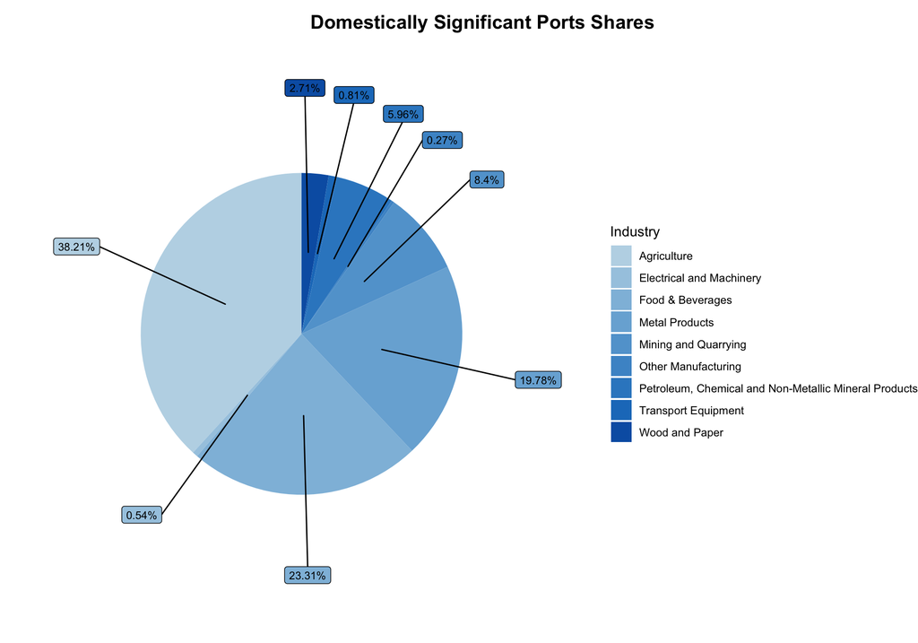

```r
# Defining a blue color palette
blue_palette <- c("#bdd7e7", "#a6cae2", "#8fbddd", "#79b0d8", "#62a3d3", "#4b96ce", "#3489c9", "#1d7cc4", "#0760b2", "#084d91")
 # setting the blue color palette

industry_df <- industry_df %>% # here I calculate the position for labels in a pie chart. The cumulative sum in reverse order helps in placing the labels correctly, ensuring they are centered within each segment
  mutate(csum = rev(cumsum(rev(Share))),
         pos = Share / 2 + lead(csum, 1),
         pos = if_else(is.na(pos), Share / 2, pos)) # here calculating pos in case of NA

# Pie chart plotting
ggplot(industry_df, aes(x="", y=Share, fill=Industry)) +
  geom_bar(stat="identity", width=1) +  # geom_bar with width=1 to create pie segments
  coord_polar("y", start = 0) +  # using coord_polar to turn the bar chart into a pie chart
  theme_void() +  # removing background and axes
  labs(title="Domestically Significant Ports Shares") +  # title
  theme(plot.title = element_text(hjust = 1.2, vjust = 0.9, size= 15, face="bold"),  # adjusting title to the right and higher position
        legend.position="right") +  # the legend on the right
   geom_label_repel(data = industry_df, # adjusting percentage labels, so that they are outside the pie chart with the corresponding share color and line directed to the share
                   aes(y = pos, label = paste0(round(Share, 2), "%")), # adjusting the percentage (2 numbers after coma)
                   size = 3, nudge_x = 1, show.legend = FALSE) +
  scale_fill_manual(values=blue_palette)  # using the defined blue color palette
```

## Mapping It Out Task

```r
unique_countries <- unique(merged_data$country)#

colors <- grDevices::colorRampPalette(c("#FFB6C1", "#AEC6CF", "#77DD77", "#FDFD96", "#CDB4DB"))(length(unique_countries))
country_colors <- setNames(colors, unique_countries)

merged_data$color <- country_colors[merged_data$country]
```

```r
fig <- merged_data %>%
  plot_ly(
    lat = ~lat,
    lon = ~long,
    marker = list(color = ~color, size = 10),
    type = 'scattermapbox',
    mode = 'markers',  # the mode is set to 'markers'
    customdata = ~portid,  # using customdata to store port IDs
    hovertext = ~paste( # below I specify what I want to see in the small window on the map near each port
      'Country:', country, '<br>',
      'Import Share:', share_country_maritime_import,'<br>',
      'Export Share:', share_country_maritime_export,'<br>'
    )
  )

fig <- fig %>% # here using plotly.com I adjust the map and its settings
  layout(
    mapbox = list(
      style = 'open-street-map',
      zoom = 1.5,  # Adjust zoom level as needed
      center = list(lon = mean(merged_data$long), lat = mean(merged_data$lat))
    ),
    title = "Global Ports Map",
       showlegend = FALSE,
    annotations = list( # adding caption for the sources
      list(
        x = 0.5,
        y = 0,
        xref = 'paper',
        yref = 'paper',
        text = "Sources: UN Global Platform; IMF PortWatch (portwatch.imf.org)",
        showarrow = FALSE,
        font = list(size = 12)
        )
    ),
    margin = list(b = 10)  # adjusting the bottom margin to make space for the manual legend
  )

# Saving the plot as an HTML file
saveWidget(fig, "fig.html", selfcontained = FALSE, libdir = "lib")
```

> The final results and interactive plotting of this world map you can see in a separate html file. Each color means unique country and its ports. I tried to add legend with color and appropriate industry but scattermapbox does not support legends for color directly as other plot types do.

## Surprise Us Task

> I have an interest in Asian countries, specifically in Japan. It’s interesting for me to investigate more its ports. That is why I will start first with creating a subset only with Japanese ports and relevant to it data.

```r
japan_ports <- merged_data %>%
  filter(country == "Japan") %>%
  dplyr :: select(portid, fullname, share_country_maritime_import, share_country_maritime_export, total)

print(japan_ports)
```

```
## # A tibble: 94 × 5
##    portid   fullname         share_country_mariti…¹ share_country_mariti…² total
##    <chr>    <chr>                             <dbl>                  <dbl> <dbl>
##  1 port1325 Tsuruga Ko, Jap…                   0.3                  0.0009   704
##  2 port1335 Ube Ko, Japan                      1.1                  0.034   5024
##  3 port1343 Uno Ko, Japan                      0.22                 0.0016   691
##  4 port1345 Uwajima Ko, Jap…                   0.01                 0.0005    79
##  5 port1378 Wakamatsu Ko, J…                   3.78                 0.0255  7311
##  6 port1379 Wakayama-Shimot…                   1.95                 0.0201  5320
##  7 port1411 Yatsushiro Ko, …                   0.25                 0.0012   499
##  8 port1412 Yawatahama, Jap…                   0.02                 0.0003    65
##  9 port1416 Yokkaichi, Japan                   1.9                  0.0139  7379
## 10 port1417 Yokohama Ko, Ja…                   4.52                 0.0506 14491
## # ℹ 84 more rows
## # ℹ abbreviated names: ¹share_country_maritime_import,
## #   ²share_country_maritime_export
```

```r
japan_ports <- japan_ports %>%
mutate(city = gsub(", Japan$", "", fullname)) # for further analysis it is better to create variable with only cities from fullname variable
```

```r
top_cities_exports <- japan_ports %>%
  group_by(city) %>%
  summarize(total_export_share = sum(share_country_maritime_export)) %>%
  arrange(desc(total_export_share)) %>%
  slice_head(n = 5)
top_cities_exports
```

```
## # A tibble: 5 × 2
##   city         total_export_share
##   <chr>                     <dbl>
## 1 Nagoya Ko                0.0595
## 2 Yokohama Ko              0.0506
## 3 Mizushima Ko             0.0494
## 4 Chiba Ko                 0.0419
## 5 Kashima Ko               0.0341
```

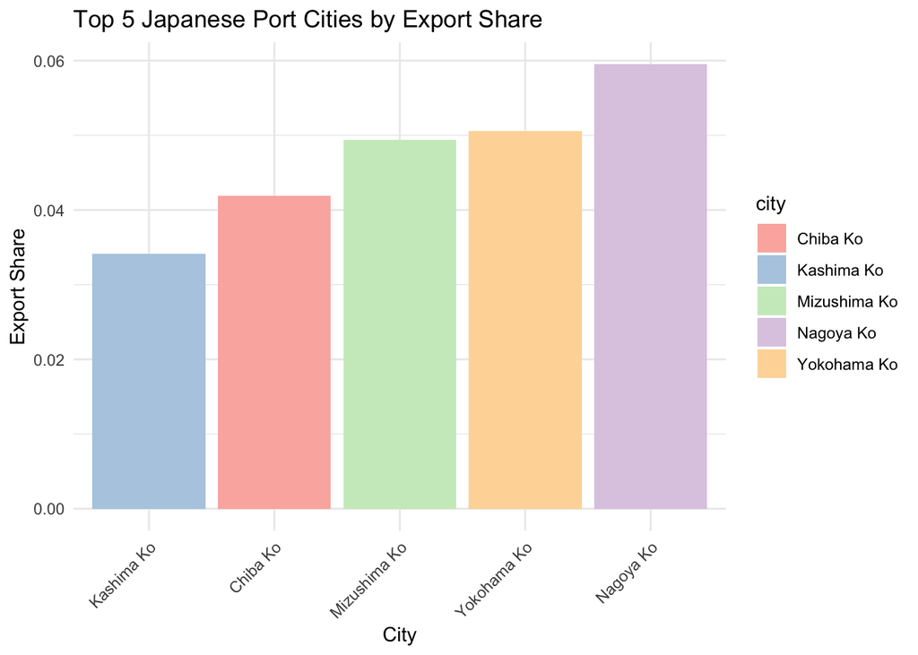

```r
# Plotting the top 5 Japanese cities by export share
ggplot(top_cities_exports, aes(x = reorder(city, total_export_share), y = total_export_share, fill = city)) +
  geom_col() +
  labs(title = "Top 5 Japanese Port Cities by Export Share",
       x = "City",
       y = "Export Share") +
  theme_minimal() +
  theme(axis.text.x = element_text(angle = 45, hjust = 1)) +
  scale_fill_manual(values = c("#fbb4ae", "#b3cde3", "#ccebc5", "#decbe4", "#fed9a6"))
```

> As the histogram shows, the largest export share belongs to Japanese city Nagoya Ko. This can be because of its geographical location, logistics and a location of Toyota Motor Corp. That is why this city is oficially nation’s largest exporter.

## Additionally, I decided to analyse the distribution of import and export shares of all given countries to identify interesting outliners.

```r
# Filter data to include only countries with at least 2 ports to avoid trivial cases
countries_with_ports <- merged_data %>%
  group_by(country) %>%
  filter(n() >= 2) %>%
  summarize(
    avg_export_share = mean(share_country_maritime_export),
    avg_import_share = mean(share_country_maritime_import),
    total_ports = n()
  )
```

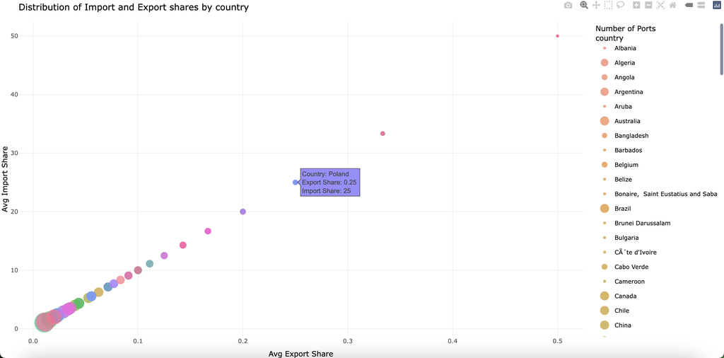

The screenshot of the interactive plot. Sources: UN Global Platform; IMF PortWatch (portwatch.imf.org)

```r
ggplot_object <- ggplot(countries_with_ports, aes(x = avg_export_share, y = avg_import_share, size = total_ports, color = country)) +
  geom_point(alpha = 0.7, aes(text = paste("Country:", country, "<br>Export Share:", round(avg_export_share, 2), "<br>Import Share:", round(avg_import_share, 2)))) +
  scale_size(range = c(1, 10)) +
  labs(title = "Distribution of Import and Export shares by country",
       x = "Avg Export Share",
       y = "Avg Import Share",
       size = "Number of Ports") +
  theme_minimal()
# Convert the ggplot object to a plotly object with tooltips
ggplotly_object <- ggplotly(ggplot_object, tooltip = "text")

# Print the interactive plot
print(ggplotly_object)

saveWidget(ggplotly_object, "interactive_plot.html", selfcontained = TRUE)
```

> Also each country has bigger or smaller radius. The larger radius - the bigger total amount of ports.

# Thank you for scrolling & looking till the end! 😊

[figure not shown]

:)